| Hazırlayan | Versiyon | Tarih | Dil |
| --- | --- | --- | --- |
| dataFLOYD | v1.01 | 30 Ağu 2018 | TR |

Daha önce bakmadıysanız veya başlangıç seviyesindeyseniz aşağıdaki yazılarımızı gözden geçirmenizi tavsiye ederim. *Sadece bu faydalı sayfaları yeniden ziyaret etmek de isteyebilirsiniz tabi, o da olumlu :)*  
[Pyhton “numpy” kütüphanesinin kullanımı](https://www.datafloyd.com/tr/pyhton-numpy-kutuphanesinin-kullanimi/)  
[Veri bilimi için temel Python kullanımı](https://www.datafloyd.com/tr/veri-bilimi-icin-temel-python-kullanimi/)  
[Python “matplotlib” kütüphanesini kullanarak veri görselleştirme – Temel Grafikler](https://www.datafloyd.com/tr/pyhton-matplotlib-kutuphanesini-kullanarak-veri-gorsellestirme-temel-grafikler%C2%B6/)

# Python "pandas" kütüphanesine giriş

Başlamadan önce size sevgili kızımın pandas (pandalar) yorumunu sunmak istiyorum.  
Ben resimde en çok kaydırağa tırmanan pandayı sevdim :)

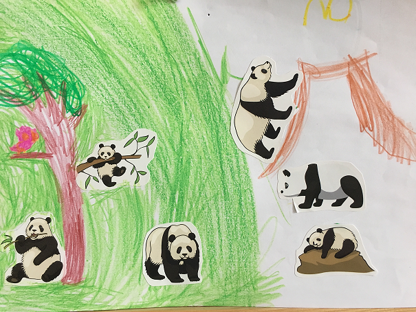

```python
from IPython.display import Image
Image(filename='pandas_enb.png')
```

Pandas Python kullanan her veribilimcinin bilmesi haberi olması gereken bir kütüphane. Resmi [web sayfasında] (https://pandas.pydata.org/pandas-docs/stable/) pandas şu şekilde tanımlanıyor:

*"pandas hızlı, esnek ve açıklayıcı veri yapıları sunan bir Python kütüphanesidir. İlişkisel ve işaretlenmiş veri ile sezgisel ve kolay bir şekilde çalışabilmek amacıyla tasarlanmıştır. Python ile gerçek dünyadaki very analizleri için temel bir yapı taşı olmayı hedeflemektedir."*  
*"pandas is a Python package providing fast, flexible, and expressive data structures designed to make working with “relational” or “labeled” data both easy and intuitive. It aims to be the fundamental high-level building block for doing practical, real world data analysis in Python"*

Pandas ile birlikte gelen temel iki veri yapısı vardır.

- Series (Seriler)
- DataFrame (Veri çerçeveleri)  
  Bu çalışmada sizlere "pandas" kullanmaya başlamak için gerekli temeli vermeyi hedefliyorum.

**SERIES**

```python
# pandas kütüphanesini ekleyelim
# genel olarak pd diye eklemek makbüldrü
import pandas as pd

# İlk Series nesnemizi yaratalım
a_pd_series = pd.Series([1,2,3,4,5,6,7,8,9,10])

# bastıralım
print(a_pd_series)
```

```
0     1
1     2
2     3
3     4
4     5
5     6
6     7
7     8
8     9
9    10
dtype: int64
```

Gördüğünüz gibi veri tipi otomatik olarak int64 olarak atanmış durumda ve iki adet sütun mevcut. İlk sütuna indeks (index) ve ikinci sütuna da değerler (values) denilmektedir.

- values ve index alanlarını görmek için:

```python
# values
print(a_pd_series.values)
# index
print(a_pd_series.index)
```

```
[ 1  2  3  4  5  6  7  8  9 10]
RangeIndex(start=0, stop=10, step=1)
```

- Serinin veri tipine ulaşmak için

```python
a_pd_series.dtype
```

```
dtype('int64')
```

- Indekslere isim verebiliriz

```python
b_pd_series = pd.Series([1,2,3,4,5],index=["bir","iki","üç","dört","beş"])
print(b_pd_series)
```

```
bir     1
iki     2
üç      3
dört    4
beş     5
dtype: int64
```

- Serinin içindeki elemanlara erişmek için indeksleri köşeli parantez için de yazmamız yeterli

```python
print(a_pd_series[3])
print(b_pd_series["iki"])
```

```
4
2
```

- "Dictionary" veri tipini kullanarak bir seri yaratmamız mümkün

```python
c_pd_series = pd.Series({"bir":1,"iki":2})
print(c_pd_series)
```

```
bir    1
iki    2
dtype: int64
```

- Kesme (slicing) metotlarını seriler üzerinde kullanabiliriz.

```python
print(a_pd_series[3:5]),
print("\n")
print(b_pd_series["iki":"dört"])
```

```
3    4
4    5
dtype: int64


iki     2
üç      3
dört    4
dtype: int64
```

- Seri nesneleri karışık veri tiplerine sahip olabilirler.

```python
d_pd_series = pd.Series(["a",3.14,42,True,1j],index=[0,1,2,3,4])
d_pd_series
```

```
0       a
1    3.14
2      42
3    True
4      1j
dtype: object
```

**DATAFRAME**

"Dataframe"ler iki boyutlu matrisler olarak düşünülebilir. Başka bir bakış açısıyla bunu bir excel dosyası olarak da değerlendirmek mümkündür. Satırların indeksi sütunların ise isimleri vardır. "Dataframe" nesneleri aynı indekse sahip seri nesnelerinin yanyana gelmiş hali gibidir.

- "numpy array" kullanarak bir "Dataframe" yaratalım

```python
# numpy kütüphanesini çağıralım
import numpy as np
# Bir "dataframe oluşturalım"
a_pd_df = pd.DataFrame(np.random.random((4,3)), # 4x3 rasgele matris oluşturalım
                       index = np.arange(4), # indeks isimleri
                       columns=["A","B","C"]) # sütun isimleri
# gösterelim
a_pd_df
```

|  | A | B | C |
| --- | --- | --- | --- |
| 0 | 0.427081 | 0.445380 | 0.823334 |
| 1 | 0.939503 | 0.702481 | 0.667594 |
| 2 | 0.321014 | 0.464830 | 0.195485 |
| 3 | 0.578744 | 0.707773 | 0.459865 |

```python
age_pd_series = pd.Series({"A":33,"B":24,"C":45,"E":18},name="yaş")
weight_pd_series = pd.Series({"A":55,"B":65,"C":75,"D":80},name="kilo") # in kg :)

# birleştirmek için pd concat fonksiyonunu kullanalım
pd.concat([age_pd_series,weight_pd_series],axis=1,sort=True)
```

|  | yaş | kilo |
| --- | --- | --- |
| A | 33.0 | 55.0 |
| B | 24.0 | 65.0 |
| C | 45.0 | 75.0 |
| D | NaN | 80.0 |
| E | 18.0 | NaN |

```python
# veya çoğunlukla yaptığımız gibi pd.DataFrame() kullanalım
pd.DataFrame({"yaş":age_pd_series,"kilo":weight_pd_series})
```

|  | yaş | kilo |
| --- | --- | --- |
| A | 33.0 | 55.0 |
| B | 24.0 | 65.0 |
| C | 45.0 | 75.0 |
| D | NaN | 80.0 |
| E | 18.0 | NaN |

- İndeksi alalım

```python
a_pd_df.index
```

```
Int64Index([0, 1, 2, 3], dtype='int64')
```

- Sütun isimlerini alalım

```python
a_pd_df.columns
```

```
Index(['A', 'B', 'C'], dtype='object')
```

**DataFrame ile birlikte sıklıkla kullanılan fonksiyonlar**